# Practical Machine Learning Final Project

## Synopsis:

Accelerometer data from participants performing barbell lifts five different ways was collected to create a model that was used to predict the classe of barbell lift for twenty sets of acceleromter data.

## Data Cleaning:

A training set and testing set were obtained from http://groupware.les.inf.puc-rio.br/har under the Weight Lifting Exercise data set.

The training set is from http://d396qusza40orc.cloudfront.net/predmachlearn/pml-training.csv The testing set of twenty sets of data for which a classe is to be predicted is from http://d396qusza40orc.cloudfront.net/predmachlearn/pml-testing.csv

Before the prediction can be made, the training set is divided into a smaller training set (75%) and validation set (25%)

```r
setwd("C:/Users/mbonifac/Desktop/Coursera/R_Portfolio")
trainmaster<-read.csv("./pml-training.csv")
#Remove the columns that are blank or have NA
working_train<-trainmaster[lapply(trainmaster,function(x) sum(is.na(x))/length(x))<0.1]
working_train[working_train == ""] <- NA
working_train<-working_train[lapply(working_train,function(x) sum(is.na(x))/length(x))<0.1]

#Remove columns that are known to not affect classe, (row number, user_name, raw_timestamp_part_1,
#raw_timestamp_part_2, cvtd_timestamp, new_window, num_window)
working_train<-working_train[,-c(1:7)]

#Divide data into a training set and a validation set (75% training/25% validation)
library(caret)
library(kernlab)
set.seed(125)
inTrain<-createDataPartition(y=working_train$classe, p=0.75, list=FALSE)
train_train<-working_train[inTrain,]
train_validate<-working_train[-inTrain,]
```

The testing set is prepared in the same manner as the working_train set with unnecessary columns removed.

```r
testmaster<-read.csv("./pml-testing.csv")

#Remove the columns that are blank or have NA
working_test<-testmaster[lapply(testmaster,function(x) sum(is.na(x))/length(x))<0.1]
working_test[working_test == ""] <- NA
working_test<-working_test[lapply(working_test,function(x) sum(is.na(x))/length(x))<0.1]

#Remove columns that are known to not affect classe, (row number, user_name, raw_timestamp_part_1,
#raw_timestamp_part_2, cvtd_timestamp, new_window, num_window)
working_test<-working_test[,-c(1:7)]
```

## Determination of Model:

The first model to attempt is the decision tree.

```r
model_tree<-train(classe~.,method="rpart",data=train_train)
library(rattle)
```

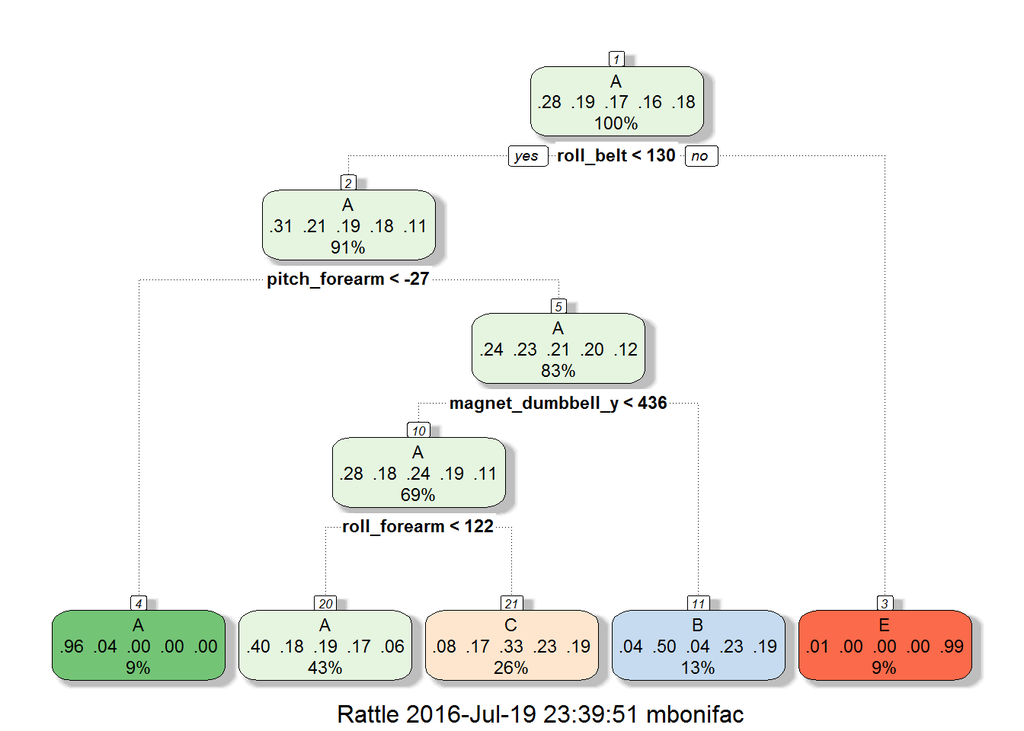

```r
fancyRpartPlot(model_tree$finalModel)
```

The decision tree model does not appear to identify classe D. Predict using the train_validate set to confirm.

```r
valid_tree<-predict(model_tree,newdata=train_validate)
confusionMatrix(valid_tree,train_validate$classe)
```

```
## Confusion Matrix and Statistics
##
##           Reference
## Prediction    A    B    C    D    E
##          A 1286  409  387  341  136
##          B   17  312   26  134  137
##          C   90  228  442  329  242
##          D    0    0    0    0    0
##          E    2    0    0    0  386
##
## Overall Statistics
##
##                Accuracy : 0.4947
##                  95% CI : (0.4806, 0.5088)
##     No Information Rate : 0.2845
##     P-Value [Acc > NIR] : < 2.2e-16
##
##                   Kappa : 0.3395
##  Mcnemar's Test P-Value : NA
##
## Statistics by Class:
##
##                      Class: A Class: B Class: C Class: D Class: E
## Sensitivity            0.9219  0.32877  0.51696   0.0000  0.42841
## Specificity            0.6372  0.92061  0.78044   1.0000  0.99950
## Pos Pred Value         0.5025  0.49840  0.33208      NaN  0.99485
## Neg Pred Value         0.9535  0.85110  0.88441   0.8361  0.88596
## Prevalence             0.2845  0.19352  0.17435   0.1639  0.18373
## Detection Rate         0.2622  0.06362  0.09013   0.0000  0.07871
## Detection Prevalence   0.5218  0.12765  0.27141   0.0000  0.07912
## Balanced Accuracy      0.7795  0.62469  0.64870   0.5000  0.71396
```

The accuracy of the decision tree model is low. The boosted model is then tried.

```r
model_boost<-train(classe~.,method="gbm",data=train_train, verbose=FALSE)
valid_boost<-predict(model_boost,newdata=train_validate)
confusionMatrix(valid_boost,train_validate$classe)
```

```
## Confusion Matrix and Statistics
##
##           Reference
## Prediction    A    B    C    D    E
##          A 1369   32    0    1    1
##          B   17  897   28    4   16
##          C    6   18  819   27    9
##          D    3    2    8  765   19
##          E    0    0    0    7  856
##
## Overall Statistics
##
##                Accuracy : 0.9596
##                  95% CI : (0.9537, 0.965)
##     No Information Rate : 0.2845
##     P-Value [Acc > NIR] : < 2.2e-16
##
##                   Kappa : 0.9489
##  Mcnemar's Test P-Value : 1.815e-08
##
## Statistics by Class:
##
##                      Class: A Class: B Class: C Class: D Class: E
## Sensitivity            0.9814   0.9452   0.9579   0.9515   0.9501
## Specificity            0.9903   0.9836   0.9852   0.9922   0.9983
## Pos Pred Value         0.9758   0.9324   0.9317   0.9598   0.9919
## Neg Pred Value         0.9926   0.9868   0.9911   0.9905   0.9889
## Prevalence             0.2845   0.1935   0.1743   0.1639   0.1837
## Detection Rate         0.2792   0.1829   0.1670   0.1560   0.1746
## Detection Prevalence   0.2861   0.1962   0.1792   0.1625   0.1760
## Balanced Accuracy      0.9858   0.9644   0.9715   0.9718   0.9742
```

## Prediction

With a much higher accuracy, the boosted model is considered for prediction of the working_test set. The boosted model is used to predict classe for the data in working_test.

```r
test_prediction<-predict(model_boost,newdata=working_test)
Prediction_Results<-data.frame(prediction=test_prediction)
Prediction_Results
```

```
##    prediction
## 1           B
## 2           A
## 3           B
## 4           A
## 5           A
## 6           E
## 7           D
## 8           B
## 9           A
## 10          A
## 11          B
## 12          C
## 13          B
## 14          A
## 15          E
## 16          E
## 17          A
## 18          B
## 19          B
## 20          B
```